# EU Farm Fish CEA - 1. Consumption Prep File

Author

Sagar Shah, Rethink Priorities

Published

March 18, 2024

# Navigation

Return to the full [Github repository](https://github.com/rethinkpriorities/farmfish_stunning_cea) for this project, or the [html version of the readme file](https://rethinkpriorities.github.io/farmfish_stunning_cea/).

# About this file

This file brings together estimates of per country EU consumption of Sea bream, Sea bass, Carp, Salmon and Rainbow Trout into a single dataset in long format.

# Preparation

## Clear environment

```r
rm(list=ls())
```

## Load packages

```r
library(readxl)
library(tidyverse)
library(scales)
library(DT)
```

# Open data files

This file contains data on:

- EU country codes (from [Eurostat](https://ec.europa.eu/eurostat/statistics-explained/index.php?title=Glossary:Country_codes))
- EUFOMA apparent consumption estimates (live weight equivalent) in various EU countries of [Seabass (2016)](https://perma.cc/9AT9-2W26), [Seabream (2019)](https://perma.cc/VQ2G-HDP5) and [Carp(2018)](https://perma.cc/3WCU-EHSY)
- Portion trout and large trout estimates come from the EUFOMA [large trout in the EU (2020)](https://perma.cc/XV5N-6B5R) study, using apparent consumption estimates for large trout and all trout respectively
- Salmon consumption estimates are extracted from the chart from page 42 of the [Mowi (2023) industry report](https://perma.cc/5BLM-5EB4) for France, Germany, Italy, Spain and Sweden only.
- Population data for EU27 countries to estimate salmon consumption (from Eurostat)

```r
xl_data <-"../1_input_data/EUFOMA_consumption_data.xlsx"
country_codes <- read_excel(xl_data,sheet = "country_codes")
bass <- read_excel(xl_data,sheet = "seabass_2016")
bream <- read_excel(xl_data,sheet = "seabream_2019")
carp <- read_excel(xl_data,sheet = "carp_2018")
trout <- read_excel(xl_data,sheet = "trout_2020")
salmon <- read_excel(xl_data,sheet = "salmon_2022_raw")
population <- read_excel("../1_input_data/country populations.xlsx",sheet = "EU27populations2022")
```

# Salmon consumption estimates

Mowi industry report only provides salmon consumption estimates for 5 EU countries. For other countries, we need estimate salmon consumption. I do this by assuming:

- per capita consumption in the Denmark and Finland is equal to per capita consumption in Sweden
- per capita consumption in Netherlands, Belgium, Austria, Luxembourg and Ireland is equal to per capita consumption in Germany
- per capita consumption in Portugal, Greece, Cyprus and Malta is equal to per capita consumption in Italy
- the remainder is equally distributed across the rest of the EU

I also assume that the Mowi industry reports estimate for EU+UK market size actually excludes the UK, based on comparisons with EUFOMA balance sheet data (https://www.eumofa.eu/supply-balance).

I first extract aggregate EU consumption of salmon…

```r
EU_salmon <- salmon %>% filter(Country=="EU27") %>% pull(Tons) %>%mean()
EU_salmon
```

```
[1] 1141000
```

I then estimate per capita consumption of salmon (in Tons) for the three reference countries, Sweden, Italy and Germany.

```r
per_capita_salmon <-
  salmon %>%
  filter(Country %in% c("Sweden","Germany","Italy")) %>%
  left_join(population,by="Country") %>%
  mutate(per_capita=Tons/pop) %>%
  select(Country,per_capita) %>%
  rename(ref_country=Country)

per_capita_salmon
```

```
# A tibble: 3 × 2
  ref_country per_capita
  <chr>            <dbl>
1 Germany        0.00285
2 Italy          0.00235
3 Sweden         0.00555
```

I then assign these per capita consumption values to selected other countries, and calculate aggregate consumption in those countries.

```r
#Assign country groups
nordic <- c("Denmark","Finland")
germanic <- c("Austria","Netherlands","Belgium","Luxembourg","Ireland")
italian <- c("Portugal","Greece","Malta","Cyprus")

#Estimate salmon consumption in these countries
salmon_ref_countries <- population %>%
  filter(Country %in% c(nordic,germanic,italian)) %>%
  mutate(
    ref_country=
    case_when(
      Country %in% nordic ~ "Sweden",
      Country %in% germanic ~ "Germany",
      Country %in% italian ~ "Italy",
      TRUE ~ "Error"
    )) %>%
  left_join(per_capita_salmon,by="ref_country") %>%
  mutate(
    Tons=pop*per_capita,
    Estimate=str_c("ref country per capita - ",str_to_lower(ref_country))) %>%
  select(Country,Tons,Estimate)

salmon_ref_countries
```

```
# A tibble: 11 × 3
   Country       Tons Estimate
   <chr>        <dbl> <chr>
 1 Belgium     33079. ref country per capita - germany
 2 Denmark     32592. ref country per capita - sweden
 3 Ireland     14407. ref country per capita - germany
 4 Greece      24630. ref country per capita - italy
 5 Cyprus       2130. ref country per capita - italy
 6 Luxembourg   1838. ref country per capita - germany
 7 Malta        1227. ref country per capita - italy
 8 Netherlands 50086. ref country per capita - germany
 9 Austria     25566. ref country per capita - germany
10 Portugal    24376. ref country per capita - italy
11 Finland     30787. ref country per capita - sweden
```

I then estimate consumption in the remainder of EU countries, by assuming per capita consumption in these countries is equal.

```r
#Estimate residual aggregate salmon consumption
salmon_residual_aggregate<- EU_salmon*2-sum(salmon$Tons)-sum(salmon_ref_countries$Tons)

#Calculate consumption in each country by multiplying aggregate by their population share
salmon_residual_countries <- population %>%
  filter(!(Country %in% c(salmon$Country,germanic,italian,nordic))) %>%
  mutate(
    Tons=pop/sum(pop)*salmon_residual_aggregate,
    Estimate="residual EU per capita"
    ) %>%
  select(-pop)

salmon_residual_countries
```

```
# A tibble: 11 × 3
   Country     Tons Estimate
   <chr>      <dbl> <chr>
 1 Bulgaria   4549. residual EU per capita
 2 Czechia    6995. residual EU per capita
 3 Estonia     886. residual EU per capita
 4 Croatia    2569. residual EU per capita
 5 Latvia     1248. residual EU per capita
 6 Lithuania  1866. residual EU per capita
 7 Hungary    6444. residual EU per capita
 8 Poland    25045. residual EU per capita
 9 Romania   12666. residual EU per capita
10 Slovenia   1402. residual EU per capita
11 Slovakia   3615. residual EU per capita
```

Finally I combine the data into final table

```r
#Combined table
salmon<-salmon %>%
  filter(Country!="EU27") %>%
  mutate(Estimate="mowi industry report") %>%
  rbind(salmon_ref_countries,salmon_residual_countries)

salmon
```

```
# A tibble: 27 × 3
   Country    Tons Estimate
   <chr>     <dbl> <chr>
 1 France  269000  mowi industry report
 2 Germany 237000  mowi industry report
 3 Italy   139000  mowi industry report
 4 Spain   130000  mowi industry report
 5 Sweden   58000  mowi industry report
 6 Belgium  33079. ref country per capita - germany
 7 Denmark  32592. ref country per capita - sweden
 8 Ireland  14407. ref country per capita - germany
 9 Greece   24630. ref country per capita - italy
10 Cyprus    2130. ref country per capita - italy
# ℹ 17 more rows
```

And check that the values look reasonable (TRUE means working ok).

```r
#Check
near(EU_salmon,sum(salmon$Tons))
```

```
[1] TRUE
```

Finally I plot some charts for reference.

Estimated salmon consumption in each EU country

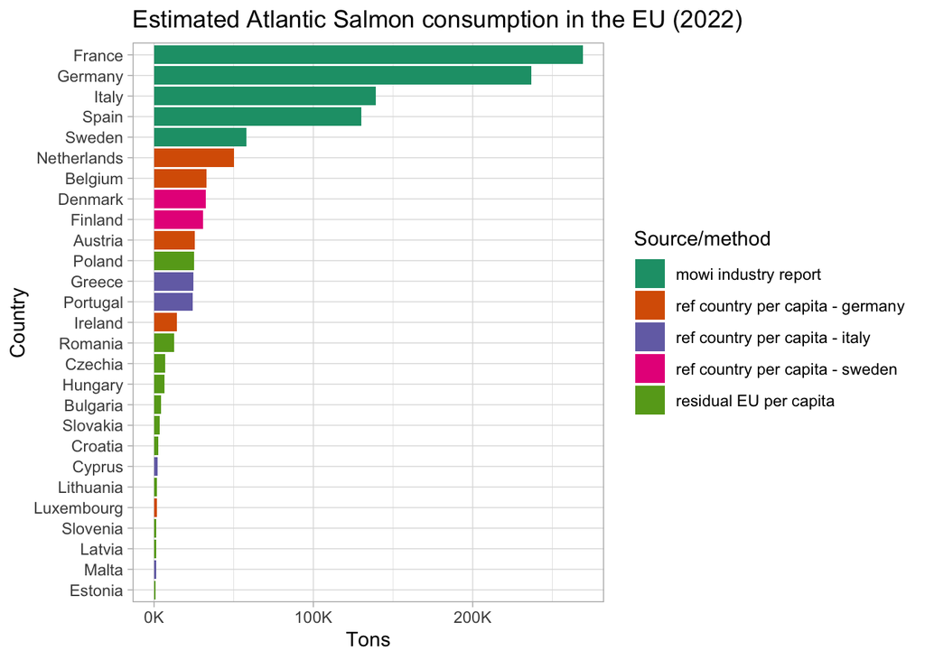

```r
salmon %>%
  ggplot(
    aes(
      x=Tons,
      y=reorder(Country,Tons),
      fill=Estimate
        )) +
   geom_col()+
   labs(
     title = "Estimated Atlantic Salmon consumption in the EU (2022)",
     y="Country",
     fill="Source/method") +
  scale_fill_brewer(palette="Dark2") +
  theme_light() +
  scale_x_continuous(labels = label_number(suffix = "K", scale = 1e-3))
```

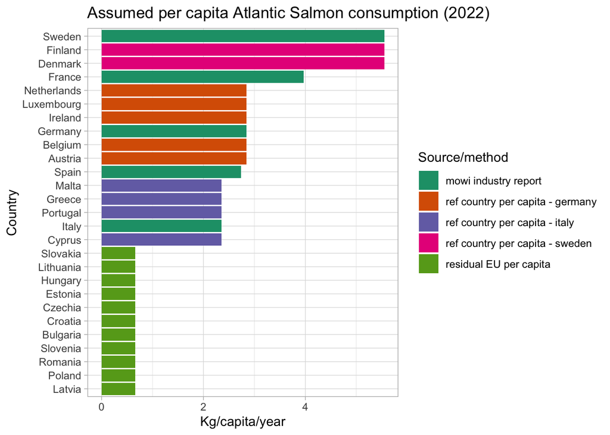

```r
salmon %>%
  left_join(population,by="Country") %>%
  mutate(per_capita=Tons*1000/pop) %>%
  ggplot(
    aes(
      x=per_capita,
      y=reorder(Country,per_capita),
      fill=Estimate
        )) +
   geom_col()+
   labs(
     title = "Assumed per capita Atlantic Salmon consumption (2022)",
     y="Country",
     x="Kg/capita/year",
     fill="Source/method") +
  scale_fill_brewer(palette="Dark2") +
  theme_light()
```

# Combine data into single file

We now prepare/clean the country species consumption data and assemble to into a “long” dataframe. Steps involved are:

1. linking country code and country code data
2. adding species names
3. apportioning consumption by portion trout and large trout share (iv) combining the species data into a single data frame
4. making column names lower case for ease of matching

```r
# Add country codes and species name
bream<- left_join(bream,country_codes,by="Code") %>% mutate(Species="Sea Bream")
bass<- left_join(bass,country_codes,by="Country") %>% mutate(Species="Sea Bass")
carp<- left_join(carp,country_codes,by="Code") %>% mutate(Species="Carp")
salmon<- left_join(salmon,country_codes,by="Country") %>% mutate(Species="Atlantic Salmon")

# Add country codes and fish size and separate into two observations
trout<- trout %>%
        left_join(country_codes,by="Code") %>%
        pivot_longer(
          cols=c("Rainbow Trout (Small)","Rainbow Trout (Large)"),
          names_to="Species",values_to="Tons"
        ) %>%
        select(-Notes,-Total)

# combine into single dataframe
cons_data <- bind_rows(bream,bass,carp,trout) %>%
             mutate(Estimate="EUFOMA") %>%
             bind_rows(salmon)


# make column names lower case and reorder
names(cons_data) <- str_to_lower(names(cons_data))
cons_data <- relocate(cons_data, species, country, code, tons)
```

We do a simple plot of the data to make sure it looks reasonable.

```r
cons_data <- cons_data %>%
  group_by(country) %>%
  mutate(total_cons=sum(tons)) %>%
  ungroup()
```

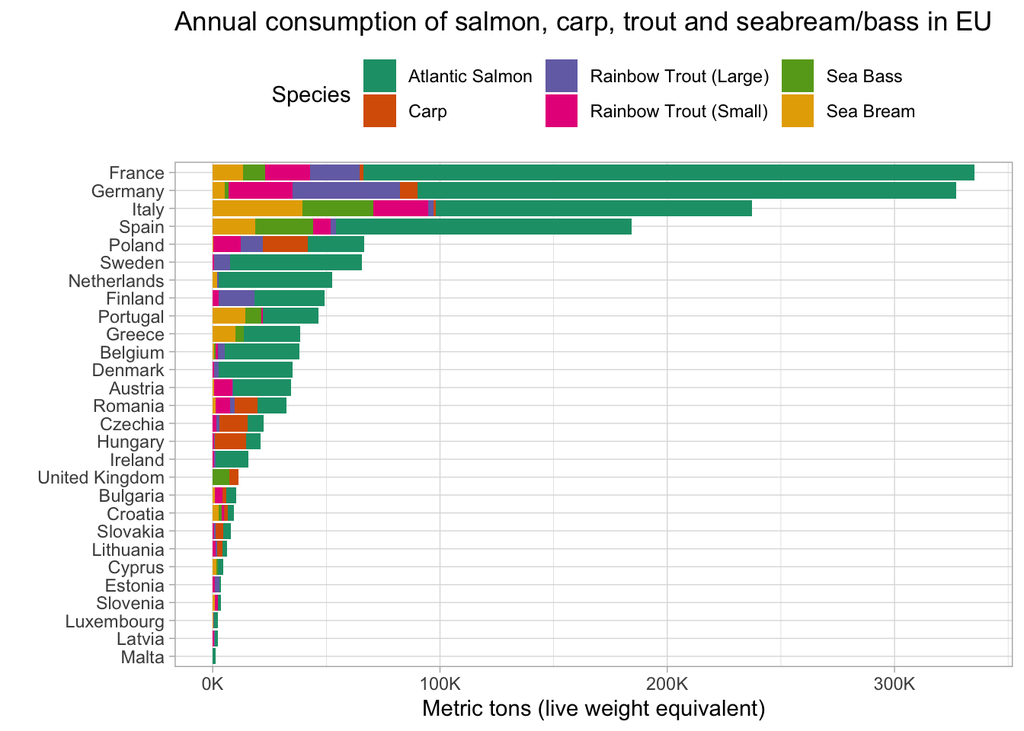

```r
cons_data %>%
  ggplot(
    aes(
      x=tons,
      y=reorder(country,total_cons),
      fill=species
      )) +
  geom_col() +
    labs(
    title = "Annual consumption of salmon, carp, trout and seabream/bass in EU",
    x = "Metric tons (live weight equivalent)",
    y = "",
    fill = "Species"
  ) +
  scale_x_continuous(labels = label_number(suffix = "K", scale = 1e-3)) +
  scale_fill_brewer(palette = "Dark2") +
  theme_light() +
  theme(legend.position = "top")
```

## Save output file

```r
saveRDS(cons_data,file= "../3_intermediate_data/cons_data.rds")
```